# Parcial 4 - Series de tiempo

¶ Exportaciones de café sin tostar en Colombia

## 1. Marco teórico

El café en Colombia, tiene alrededor de 300 años de historia desde que los jesuitas lo trajeron en el siglo XVIII. En el año 1835 se exportaban los primeros sacos producidos en la zona oriental, desde la aduana de Cúcuta. El café es uno de los productos que más ha contribuido al crecimiento de la financiación de la balanza de pagos, el empleo y la estabilidad monetaria y cambiaria en Colombia, aunque en los últimos años la exportación se ha reducido, debido a varios factores como lo son el clima, los altos precios de los insumos agrícolas, el envejecimiento de las plantas y de los caficultores, la sustitución del café por otros cultivos( aguacate, frutas, palma, etc). Cabe resaltar que, la industria del café jalona la mayor parte de la mano de obra en el país. De ahí la importancia de esta actividad como motor potencial para reducir la pobreza y distribuir el ingreso en la población rural.

Como resultado del exceso de oferta de café en los mercados y la gran acumulación de inventarios por parte de los países importadores, se presentó una reducción en los precios de más del 70 % entre 1996 y 2002 según Bloomberg. La notable participación de Vietnam como productor de café hizo que fuera el segundo productor durante 1999 y 2000, lugar que ocupaba Colombia, quien años más tarde recuperó dicho puesto cuando la producción de Vietnam se redujo de 14,8 millones de sacos al año a casi 5 millones.

> Hasta la fecha Colombia ha exportado más de USD 1.125 millones en valor FOB de cafés sin tostar y descafeinar, y se espera que para los próximos meses se aproveche el incremento en los precios y así se superen los valores registrados en el 2020 cuando, en medio de la pandemia, Colombia exportó cerca de USD 2.445 millones en valor FOB.

## 2. Lectura y depuración de la base de datos

```r
# Base orginal, cargada desde el sitio del DANE
base_compl <- read_excel("anexo-exportaciones-cafe-carbon-petroleo-ferroniquel-no-tradicionales-sep22.xlsx",
                         skip=12) %>% clean_names()
kable(base_compl[c(1:3,12:15), 1:6])%>% kable_styling(latex_options = c("condensed")) %>% row_spec(row = c(5,6), background = "#3C8483",bold = TRUE)
```

| x1 | x2 | miles_de_dolares_fob_3 | toneladas_metricas_4 | x5 | miles_de_dolares_fob_6 |
| --- | --- | --- | --- | --- | --- |
| 33604 | NA | 108864.26 | 67119.24 | 0 | 39350.42 |
| 33635 | NA | 114798.51 | 73666.14 | 0 | 56115.59 |
| 33664 | NA | 89464.46 | 61684.86 | 0 | 11971.48 |
| 33939 | NA | 128413.25 | 101672.40 | 0 | 68122.23 |
| Totales 92 | NA | 1258847.64 | 966836.16 | 0 | 555430.32 |
| NA | NA | NA | NA | NA | NA |
| 33970 | NA | 107954.78 | 68735.82 | 0 | 35891.91 |

- La base de datos sobre exportaciones en Colombia tenía al finalizar cada año 2 filas de más, una con valores NA’s y otra con los totales anuales. Para facilidad del ejercicio, ya que no aportaba algo significativo en cuanto a fechas, se eliminaron estas dos filas presentes al finalizar cada año.

```r
# Se selecciona solo las variables correspondientes a fecha y valor
# en miles de dolares de las exportaciones de café en Colombia
base <- base_compl[1:442, c(1,3)] %>%
  rename("valor" = "miles_de_dolares_fob_3") %>%
  na.omit(base) #eliminar fila de NA presente en la base original

# crea un vector que contiene las filas de los totales por año,
# para luego eliminar esas observaciones de la base de datos.
x <- seq(13, 399, by=13)
base <- base[-(x), ]
exp_cafe <-  data.frame(fecha=seq(as.Date("1992/1/1"),
                                  as.Date("2022/9/1"), "months"),
                        valor=base[1:369, 2])

# El valor correspondiente a las exportaciones en miles dolares FOB,
# se dividio en cien mil dolares quedando el valor de las exportaciones
# en una cifra de cien millonesdes de dolares FOB.

exp_cafe$valor <- exp_cafe$valor/100000

kable(exp_cafe %>% head(4),align = "c")%>% kable_styling(latex_options = c("condensed"), position = "center")
```

| fecha | valor |
| --- | --- |
| 1992-01-01 | 1.0886426 |
| 1992-02-01 | 1.1479851 |
| 1992-03-01 | 0.8946446 |
| 1992-04-01 | 1.1353458 |

```r
kable(exp_cafe %>% tail(4),align = "c")%>% kable_styling(latex_options = c("condensed"), position = "center")
```

|  | fecha | valor |
| --- | --- | --- |
| 366 | 2022-06-01 | 3.525042 |
| 367 | 2022-07-01 | 3.791430 |
| 368 | 2022-08-01 | 3.083797 |
| 369 | 2022-09-01 | 3.239474 |

- La base de datos tiene un total de 369 observaciones, la cual contiene información mensual.

### Sobre la serie de tiempo

- Se transforma el data frame creado con la fecha y el valor de las exportaciones (millones de solares FOB) a formato ts, que va desde **enero 1992** hasta **septiembre 2022**

```r
serie_original <- ts(exp_cafe$valor, start=c(1992,1), frequency = 12)
# Información de la serie
ts_info(serie_original)
```

```
##  The serie_original series is a ts object with 1 variable and 369 observations
##  Frequency: 12
##  Start time: 1992 1
##  End time: 2022 9
```

- Gráfico de la serie original completa (todas las fechas)

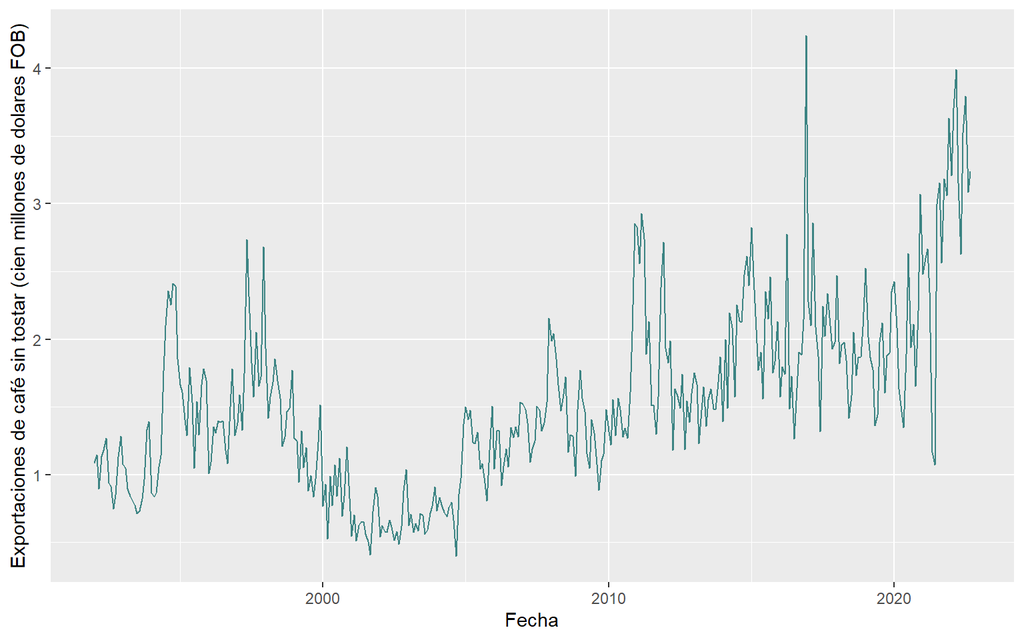

```r
exp_cafe %>% ggplot(aes(x=fecha, y=valor))+geom_line(col="#3C8483")+labs(x = "Fecha", y = "Exportaciones de café sin tostar (cien millones de dolares FOB)")
```

### Sobre la gráfica:

- Se observa una disminución considerable de las exportaciones de café sin tostar aproximadamente en los años 1998 y 2003, y esto era de esperarse, ya que como se dijo en el marco teórico, en estos años ocurrió un exceso de ofertas de café en el mundo.
- Del gráfico tambien se puede observar que no hay estabilidad en la variabilidad de la serie, y la presencia de alguno valores atípicos en el año 2016 y cerca del 2020- 2021, que se sospecha ocurrió por la pandemia mundial.
- Se observa además un componente estacional.

## 3. Modelos planteados

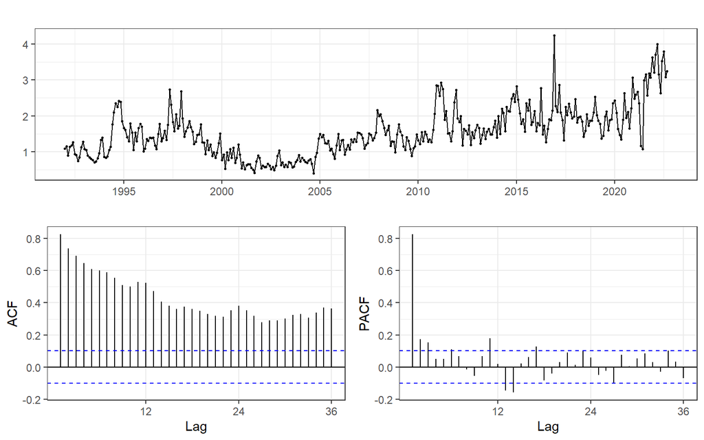

```r
ggtsdisplay(serie_original, theme = theme_bw())
```

Cómo se pudo observar en la gráfica de la serie, esta parece tener un comportamiento de una serie multiplicativa, por lo tanto se quiere realizar una trasnformación **BOXCOX** de los datos, para llegar a estabilizar la varianza y poder lograr mejores “predicciones” de las exportaciones de café.

Por lo tanto se plantean 4 modelos para ajustar la serie:

```r
train <- window(serie_original, start=time(serie_original)[1],
                end = time(serie_original)[length(serie_original) - 12])
ts_info(train)
```

```
##  The train series is a ts object with 1 variable and 357 observations
##  Frequency: 12
##  Start time: 1992 1
##  End time: 2021 9
```

```r
test <- window(serie_original, start = time(serie_original)[length(serie_original)
                                          - 12 + 1],
               end = time(serie_original)[length(serie_original)])
ts_info(test)
```

```
##  The test series is a ts object with 1 variable and 12 observations
##  Frequency: 12
##  Start time: 2021 10
##  End time: 2022 9
```

```r
#transformación de la serie:

cafe_lambda <- BoxCox.lambda(serie_original)

cafe_lambda
```

```
## [1] 0.0220795
```

```r
#lAMBDA DE LA TRANSFROMACIÓN BOXCOX

serie_boxcox <- BoxCox(serie_original,
                         lambda=cafe_lambda)

train_bc <- window(serie_boxcox, start=time(serie_original)[1],
                end = time(serie_boxcox)[length(serie_boxcox) - 12])
ts_info(train_bc)
```

```
##  The train_bc series is a ts object with 1 variable and 357 observations
##  Frequency: 12
##  Start time: 1992 1
##  End time: 2021 9
```

```r
test_bc <- window(serie_boxcox, start = time(serie_boxcox)[length(serie_boxcox)
                                          - 12 + 1],
               end = time(serie_boxcox)[length(serie_boxcox)])
ts_info(test_bc)
```

```
##  The test_bc series is a ts object with 1 variable and 12 observations
##  Frequency: 12
##  Start time: 2021 10
##  End time: 2022 9
```

#### Modelos con la base sin transformar.

- Modelo 1:

```r
mod1 <- auto.arima(train, stepwise = FALSE, approximation = FALSE)
mod1
```

```
## Series: train
## ARIMA(1,1,2)(2,0,0)[12]
##
## Coefficients:
##          ar1      ma1     ma2    sar1    sar2
##       0.8176  -1.2997  0.3185  0.2053  0.1798
## s.e.  0.0739   0.1075  0.0963  0.0571  0.0590
##
## sigma^2 = 0.1154:  log likelihood = -119.33
## AIC=250.65   AICc=250.9   BIC=273.9
```

- Significancia de los parámetros

```r
mod1 %>% coeftest
```

```
##
## z test of coefficients:
##
##       Estimate Std. Error  z value  Pr(>|z|)
## ar1   0.817596   0.073852  11.0707 < 2.2e-16 ***
## ma1  -1.299684   0.107541 -12.0855 < 2.2e-16 ***
## ma2   0.318512   0.096299   3.3075 0.0009412 ***
## sar1  0.205346   0.057067   3.5983 0.0003203 ***
## sar2  0.179811   0.059024   3.0464 0.0023160 **
## ---
## Signif. codes:  0 '***' 0.001 '**' 0.01 '*' 0.05 '.' 0.1 ' ' 1
```

- Chequeo de los residuales del modelo

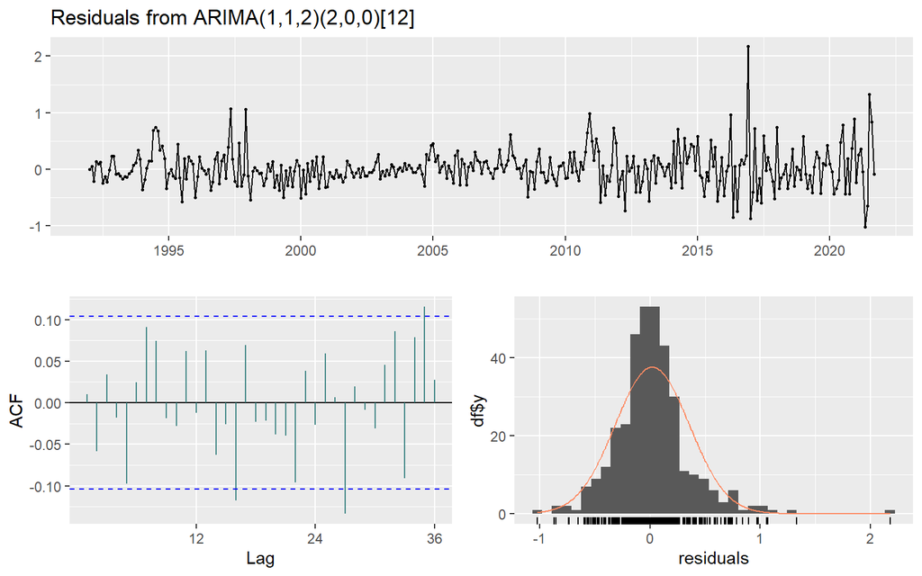

```
##
##  Ljung-Box test
##
## data:  Residuals from ARIMA(1,1,2)(2,0,0)[12]
## Q* = 28.625, df = 19, p-value = 0.07211
##
## Model df: 5.   Total lags used: 24
```

```r
mod1 %>% checkresiduals(color =c("#3C8483"))
```